# Signal Subgraphing for Batch Effect Detection with Parametric Bootstrap Null

Eric Bridgeford

November 29, 2017

```r
# load packages
#==========================#
require(fmriutils)
require(VCA)
require(stringr)
require(lme4)
require(RColorBrewer)
require(oro.nifti)
require(reshape2)
require(latex2exp)
require(ggplot2)
require(Rmisc)
require(subgraphing)
require(abind)

# functions
#==========================#

xscale.log2 <- function(a=3, b=6, n=10) {
  return(round(2^(seq(a, b, length.out=n))))
}

xscale.log10 <- function(a=1, b=3, n=10) {
  return(round(10^(seq(a, b, length.out=n))))
}

# accepts a matrix and thresholds/binarizes it
thresh_matrix = function(matrix, thresh=0.5) {
  thr = quantile(matrix, thresh)
  return(ifelse(matrix > thr, 1, 0))
}
```

# Setting

## Task

Given:

- $\mathbb{G}: \Omega \rightarrow \mathcal{G}$ is a graph-valued RV with samples $G_i \sim \mathbb{G}$.
- For each $G_i \in \mathcal{G}$, we have $G_i = (V, E_i)$; that is, each $G_i$ is defined by a set of vertices $V$ and a set of edges $E_i$, where $w_i: V \times V \rightarrow \{0, 1\}$, and $w_i(e_{uv}) \in \{0, 1\}$. That is, each graph has binary edges.
- We have a collection of classes $\mathcal{Y}$ where the collection of graphs in class $y_i$ have a class-conditional difference with the collection of graphs in class $y_j$ for $i \neq j$ comprising the signal present in the graphs.
- $\mathbb{A}_{y, z}: \Omega \rightarrow \mathcal{A}_{y, z}$, an adjacency-matrix-valued RV with samples $A_{i | y_i = y, z_i = z} \sim \mathbb{A}_{y, z}$, where $\mathcal{A}_{y, z}$ is the space of possible adjacency-matrices and $A_{i | y_i = y, z} \in \mathcal{A}_y$.
- $A_{i | y_i = y, z_i = z} \in \mathcal{A}_{y, z}$, and $\mathcal{A}_{y, z} \subseteq \mathbb{R}^{V \times V}$.
- Each graph $G_i$ can be represented as an adjacency-matrix $A_i$.
- Within each graph, there exists some collection of edges $\mathcal{S}$ called the subgraph that contain the bulk of the class differences between the $y$s.
- Class labels $z_i \in Z$, where $Z$ is a set of variables that will contribute random noise to our observations. This will be referred to as the batch-effect.

Characterize the composition of signal to batch-effect present in the given connectomes, assuming both the fixed-effects and random-effects can be characterized as random inputs in a standard mixed-effects model.

## Model

Assume that the edge weights can be characterized by a bernoulli RV; that is:

$$\begin{align}
\mathbb{A}_{uv | y, z} \sim Bern(p_{uv| y, z})
\end{align}$$

where $p_{uv| y, z}$ is the probability of edge $e_{uv}$ being connected for $y, z$.

Then our likelihood function is simply:

$$\begin{align}
L_{\mathbb{A}}(A_i; \theta) &= \prod_{(u, v) \in E_i} Bern(w_i(e_{uv}); p_{uv}) \\
&= \prod_{(u, v) \in E_i} p_{uv}^{w_i(e_{uv})}(1 - p_{uv})^{1 - w_i(e_{uv})}
\end{align}$$

# Estimators

## Bernoulli Parameters

Using MLE, it is easy to see that:

$$\begin{align}
\hat{p}_{uv} = \frac{1}{n} \sum_{i=1}^n w_i(e_{uv})
\end{align}$$

where $w_i(e_{uv}) \in \{0, 1\}$ is the binary edge weight of edge $e_{uv}$.

Note that if $w_i(e_{uv}) = 0 \;\forall i$, then $p_{uv} = 0$, which is undesirable since we only have a finite sample (and successive samples where $w_i(e_{uv})) \neq 0$ would lead to poor model performance), and vice versa for $p_{uv} = 1$ when $w_i(e_{uv}) = 0 \;\forall i$. Then consider the smoothed estimator:

$$\begin{align}
p_{uv} = \begin{cases}
n_n & max_{i}(w_i(e_{uv})) = 0 \\
1-n_n & max_{i}(w_i(e_{uv})) = 1 \\
p_{uv} & else
\end{cases}
\end{align}$$

## Priors

Here, we take the maximum likelihood estimators for the prior probabilities, which assuming our data is sampled iid from our population, should suffice:

$$\begin{align}
\hat{\pi}_y = \frac{n_y}{n}
\end{align}$$

where $n_y = \sum_{i =1}^n \mathbb{I}\{y_i = y\}$.

## Incoherent Subgraph

### Test

- [Fisher’s Exact Test](https://en.wikipedia.org/wiki/Fisher%27s_exact_test): Given the following contingency table:

| Edge | Class 1 | Class 2 |
| --- | --- | --- |
| Present | a | b |
| Not Present | c | d |

where $a=n_{uv | y = 1}$, $b=n_{uv | y = 2}$, $c=n_{y = 1} - n_{uv | y = 1}$, $d=n_{y = 1} - n_{uv | y = 1}$.

we can test whether the differences of proportions we identify is significant with the following test:

$$\begin{align*}
H_0: \textrm{the difference of proportions is insigificant} \\
H_A: \textrm{the difference of proportions is significant}
\end{align*}$$

Assuming the contingency table follows the [hypergeometric distribution](https://en.wikipedia.org/wiki/Hypergeometric_distribution), we can formulate the following test-statistic:

$$\begin{align*}
\mathcal{T}_{fisher, uv} = \frac{\begin{pmatrix}n_{uv} \\ a_{uv} + b_{uv}\end{pmatrix}\begin{pmatrix}c_{uv} + d_{uv} \\ c_{uv}\end{pmatrix}}{\begin{pmatrix}n_{uv} \\ a_{uv} + c_{uv}\end{pmatrix}}
\end{align*}$$

where $n = a_{uv} + b_{uv} + c_{uv} + d_{uv}$.

### P-value

We can compute a p-value of falsely rejecting the null hypothesis by simply finding the area:

$$\begin{align*}
p = \int_{-\mathcal{T}_{observed}}^{\infty}p(x) dx = 1 - \int_{-\infty}^{\mathcal{T}_{observed}} p(x)dx
\end{align*}$$

Fisher has shown that the probability of obtaining any such set of values is exactly the test-statistic, so $p = \mathcal{T}_{observed}$.

### Power

The statistical power can be computed as the inverse of the probability of making a Type II ($\beta$) error, $1 - \beta$. A type II error can be defined as follows:

$$\begin{align*}
\beta = \mathbb{P}(\textrm{reject $H_A$ in favor of $H_0$ | $H_A$ is true}) = \mathbb{P}(\mathcal{T}_{observed} < \mathcal{T}_{critical})
\end{align*}$$

In this case, $\mathcal{T}_{critical} = \alpha$, and $\mathcal{T}_{observed} = p$. We can formulate synthetic testing power using a post-hoc test.

## pseudo-code

To estimate the incoherent subgraph, we consider the following algorithm:

incoherent_subgraph(G, e):

- assemble a contingency matrix, per edge, counting the number of occurences of a graph from each class having or not having a connection.
- compute the p-value of Fisher’s exact test on the contingency matrix for each edge to produce the test statistic $\mathcal{T}_{uv}$. The $p$ value signifies the probability of the null hypothesis, that there is no class-conditional difference present for edge $uv$, versus the alternative that there is a class-conditional difference present for edge $uv$.
- order the test statistics in increasing order, such that $\mathcal{T}^{(1)}_{uv} \leq \mathcal{T}^{(2)}_{u'v'} \leq ...$ for all the edges.
- choose the first $e$ edges as estimator of the signal-subgraph $\hat{\mathcal{S}}$.

## Investigation

For our investigation, we will compute the within-study sub-graphs relative the sex-label, and the within-modality sub-graphs relative the sex-label. We will then perform a synthetic, parametric bootstrap to determine the significance of any present difference in the within-study vs. within-modality sub-graphs.

# Real Data

```r
sig = 0.01  # global param for significance threshold
nrep = 200  # number of replicates for synthetic bootstrap to get null

# Sum of Squared Residual Test Statistic
#
# local [n, n, d]: is the sum of all dataset ssgs estimated
# global [n, n]: is the globally estimated ssg using all of the data points
tstat.ssr <- function(local, global) {
  local <- apply(local, c(1,2), sum)
  return(sum((local/max(local) - global)^2))
}

# Jaccard Index Test Statistic
# returns mean jaccard index btwn the ssgs within dataset and global
tstat.jaccard <- function(local, global) {
  d <- dim(local)[3]
  idx.glob <- which(global > 0)
  jaccard <- array(0, dim=c(d))
  for (i in 1:dim(local)[3]) {
    idx.loc <- which(local[,,i] > 0)
    jaccard[i] <- length(intersect(idx.loc, idx.glob))/length(union(idx.loc, idx.glob))
  }
  return(mean(jaccard))
}

parse_class <- function(basepath, dsets, subjects) {
  sex = list()
  # disease = list()
  age = list()
  include = c()
  for (dset in dsets) {
    path_to_file = file.path(basepath, paste(dset, "_phenotypic_data.csv", sep=""))
    tab = read.csv(path_to_file)
    tab$SEX[tab$SEX == '#' | is.na(tab$SEX) | is.nan(tab$SEX)] = NaN
    if (dset == 'KKI2009') {
      sexm <- 'M'
    } else if (dset == 'Templeton114') {
      sexm <- 1
    } else {
      sexm <- 2
    }
    tab$AGE_AT_SCAN_1 <- factor(tab$AGE_AT_SCAN_1)
    tab$SEX = tab$SEX == sexm
    tab = tab[complete.cases(tab$SEX),]
    tab$AGE_AT_SCAN_1 = as.numeric(levels(tab$AGE_AT_SCAN_1))[tab$AGE_AT_SCAN_1]
    for (idx in 1:dim(tab)[1]) {
      subid = toString(tab[idx,]$SUBID)
      sex[[subid]] = tab[idx,]$SEX
      age[[subid]] = tab[idx,]$AGE_AT_SCAN_1
      # disease[[subid]] = tab[idx,]$DSM_IV_TR
    }
  }

  sclass = array(NaN, dim=c(length(subjects)))
  ageclass = sclass
  # diseaseclass = sclass
  for (i in 1:length(subjects)) {
    subject = subjects[i]
    subid = sub('^0+(?=[1-9])', '', str_extract(subject, '(?<=sub-).*'), perl=TRUE)
    idx = which(names(sex) == subid)
    if (length(idx) >= 1) {
      sclass[i] <- sex[[subid]]
      ageclass[i] <- age[[subid]]
      # diseaseclass[i] <- disease[[subid]]
    }
  }
  return(list(sex=sclass, age=ageclass))#, disease=diseaseclass))
}


model.alternative <- function(samp, Y, Z, global.ssg, tstat=tstat, sig=.01, verb=FALSE, classify=FALSE) {
  zset = unique(Z)
  global.sz <- sum(global.ssg > 0)
  # alternate consists of the tstat computed between the subgraphs estimated per-z
  # with the global sub-graph
  zset.sz <- array(NaN, dim=c(length(zset)))
  if (classify) {
    lhat <- array(NaN, dim=c(length(zset)))
  }
  alt.ssgs <- array(0, dim=c(nroi, nroi, length(zset)))  # save the ssgs per dataset
  for (i in 1:length(zset)) {
    ss = Z == zset[i]
    subset.gr = samp[,,ss]
    subset.Y = Y[ss]
    sg_ests <- sg.bern.subgraph_estimator(subset.gr, subset.Y)
    # compute test statistics per edge from the contingency matrix
    tstats <- sg.bern.edge_test(sg_ests$cont_matrix)
    sg_edge <- sg.bern.subgraph_edge_estimation(tstats, global.sz)
    sg <- array(0, dim=c(nroi, nroi))
    sg[sg_edge] <- 1
    alt.ssgs[,,i] <- sg
    if (classify) {
      Yhat <- sg.bern.subgraph_classifier(subset.gr, sg_edge, sg_ests$p, sg_ests$pi, sg_ests$classes)
      lhat[i] <- (sum(ss) - sum(Yhat$Yhat == Y[ss]))/sum(ss)
    }
  }

  tstat.alt <- do.call(tstat, list(alt.ssgs, global.ssg))
  ret <- list(tstat.alt=tstat.alt, alt.ssgs=alt.ssgs)
  if (classify) {
    ret$lhat <- lhat
  }
  return(ret)
}

#model.null.bootstrap <- function(samp, Y, )

# parametric bootstrap code to compute whether under the independent edge model there exists a batch effect
# samp: [n n s] array consisting of our sample.
# Y: [s] array consisting of our set of signal labels.
# Z: [s] array consisting of our set of batch-effect labels.
# nrep: [1] the number of replicates of our bootstrapped simulation.
parametric_bootstrap <- function(samp, Y, Z, nrep=100, tstat=tstat, sig=.01, verb=FALSE) {
  zset <- unique(Z)
  global.est <- sg.bern.subgraph_estimator(samp, Y)
  # compute test statistics per edge from the contingency matrix
  global.tstat <- sg.bern.edge_test(global.est$cont_matrix)
  global.ssg <- 1*(global.tstat < sig)
  global.sz <- sum(global.ssg)
  # alternate consists of the tstat computed between the subgraphs estimated per-z
  # with the global sub-graph
  result.alt <- model.alternative(samp, Y, Z, global.ssg, tstat=tstat, sig=sig, verb=verb, classify=TRUE)
  tstat.alt <- result.alt$tstat.alt
  alt.ssgs <- result.alt$alt.ssgs
  alt.lhat <- result.alt$lhat
  ct.ssg.alt <- apply(alt.ssgs, c(1,2), sum)
  alt.counts <- array(0, dim=c(length(zset)+1))
  for (i in 1:length(alt.counts)) {
    alt.counts[i] <- sum(ct.ssg.alt == (i - 1))
  }
  # null consists of the tstat computed between the subgraphs of synthetic samples
  # given P.hat, the probability matrix of the entire sample, P[i].hat, the class-conditional Pmatrix for class i
  # construct P0.syn and P1.syn, which are comprised with P[i].syn(u, v) = P.hat(u, v) when (u, v) \notin S, the global subgraph
  # and P[#].syn(u, v) = P[#].hat(u, v) when (u, v) \in S
  # that is, construct  class-conditional probability matrices where if there does not exist any batch-effect across the Zs,
  # we will get the distribution of the null that the samples within each study are chosen independently with the same P
  Y.class <- global.est$classes
  P <- sg.bern.graph_estimator(samp)$p  # get P for the entire dataset, and use P0 and P1 from dwi.global.est above
  Pclass <- array(NaN, dim=c(nroi, nroi, length(global.est$classes)))
  for (k in 1:length(Y.class)) {
    pclass <- P
    classp <- global.est$p[,,k]
    pclass[global.ssg > 0] <- classp[global.ssg > 0]
    Pclass[,,k] <- pclass
  }

  tstat.null <- array(NaN, dim=c(nrep))
  null.counts <- array(0, dim=c(length(zset) + 1))
  for (i in 1:nrep) {
    null.ssgs <- array(0, dim=c(nroi, nroi, length(zset)))
    for (j in 1:length(zset)) {
      ss = Z == zset[j] # compute which indices correspond to our current study
      subset.Y = Y[ss]  # partition the class abels for the study we want to construct synthetic data under the null for
      ns <- array(0, dim=c(length(global.est$classes)))
      dats <- list()  # synthetic null data
      labs <- list()  # labels for synthetic null data
      for (k in 1:length(global.est$classes)) {
        ns[k] <- sum(subset.Y == global.est$classes[k])  # compute the number of each class we will sample for this synthetic study
        dats[[k]] <- sg.bern.sample_graph(Pclass[,,k], s=ns[k])
        labs[[k]] <- array(global.est$classes[k], dim=c(ns[k]))
      }
      dset.null.dat <- abind(dats, along=3)
      dset.null.labs <- abind(labs, along=1)
      sg_ests <- sg.bern.subgraph_estimator(dset.null.dat, dset.null.labs)
      # compute test statistics per edge from the contingency matrix
      tstats <- sg.bern.edge_test(sg_ests$cont_matrix)
      sg_edge <- sg.bern.subgraph_edge_estimation(tstats, global.sz)
      sg <- array(0, dim=c(nroi, nroi))
      sg[sg_edge] <- 1
      null.ssgs[,,j] = sg
    }
    # count the number of times each edge appears in the ssg per-dataset
    ct.ssg.null <- apply(null.ssgs, c(1,2), sum)
    for (j in 1:length(null.counts)) {
      null.counts[j] <- null.counts[j] + sum(ct.ssg.null == (j - 1))
    }
    if (verb) {
      print(i)
    }
    tstat.null[i] <- do.call(tstat, list(null.ssgs, global.ssg))
  }
  #result.null <- model.null(samp, Y, Z, Pclass, global.est)
  #tstat.null <- result.null$tstat.null
  #null.ssgs <- result.null$null.ssgs
  return(list(p=sum(tstat.null < tstat.alt)/nrep, tstat.null=tstat.null, tstat.alt=tstat.alt,
         alt.ssgs=alt.ssgs, null.ssgs=null.ssgs, global.ssgs=global.ssg, zset=zset,
         null.counts=null.counts/sum(null.counts), alt.lhat=alt.lhat, alt.counts=alt.counts/sum(alt.counts)))
}

plot.zset <- function(zset, zset.ssgs, lhat=NaN) {
  zset_plots <- list()
  counter <- 1
  for (i in 1:length(zset)) {
    title = dwi.dsets[i]
    if (!is.nan(lhat)) {
      title = TeX(sprintf('%s, $\\hat{L}=$%.4f', title, lhat[i]))
    }
    zset_plots[[counter]] <- fmriu.plot.plot_graph(zset.ssgs[,,i],  legend.name=TeX("$I_{uv}$"),
                        title=title,
                        limits=c(min(zset.ssgs), max(zset.ssgs)), xlabel = "ROI",
                        ylabel = "ROI") + theme(legend.position=NaN)
    counter <- counter + 1
  }

  return(multiplot(plotlist = zset_plots, cols = ceiling(sqrt(length(zset)))))
}
```

## Diffusion

```r
nroi = 70
atlases = c("desikan")
dwi.dsets = c('BNU1', 'BNU3')

graphobj <- fmriu.io.collection.open_graphs(basepath='/data/dwi/edgelists/', datasets = dwi.dsets,
                                            atlases = atlases, gname = "graphs", fmt='edgelist', rtype='array')
```

```
## [1] "opening graphs for BNU1 dataset and desikan parcellation atlas..."
## [1] "opening graphs for BNU3 dataset and desikan parcellation atlas..."
```

```r
graphs = graphobj$graphs
```

```r
gcpy = graphs
datasets = graphobj$dataset
subjects = graphobj$subjects
sessions = graphobj$sessions

sexpath = '/home/eric/Documents/research/mgc-repos/fmribatch_notes/data/phenotypic_data/'
class = parse_class(sexpath, dwi.dsets, subjects)
sexs = class$sex
# dwi.diseases = class$disease
ages = class$age

dwi.graphs = graphs[!is.nan(ages) & !is.nan(sexs),,]
dwi.datasets = datasets[!is.nan(ages) & !is.nan(sexs)]
dwi.subjects = subjects[!is.nan(ages) & !is.nan(sexs)]
dwi.sessions = sessions[!is.nan(ages) & !is.nan(sexs)]
dwi.ages = ages[!is.nan(ages) & !is.nan(sexs)]
dwi.sexs = sexs[!is.nan(ages) & !is.nan(sexs)]
```

We conduct a synthetic bootstrap investigation following the above procedure:

we first visualize our set of subgraphs computed from each study using the sex class label and study as the batch label (the alternative model):

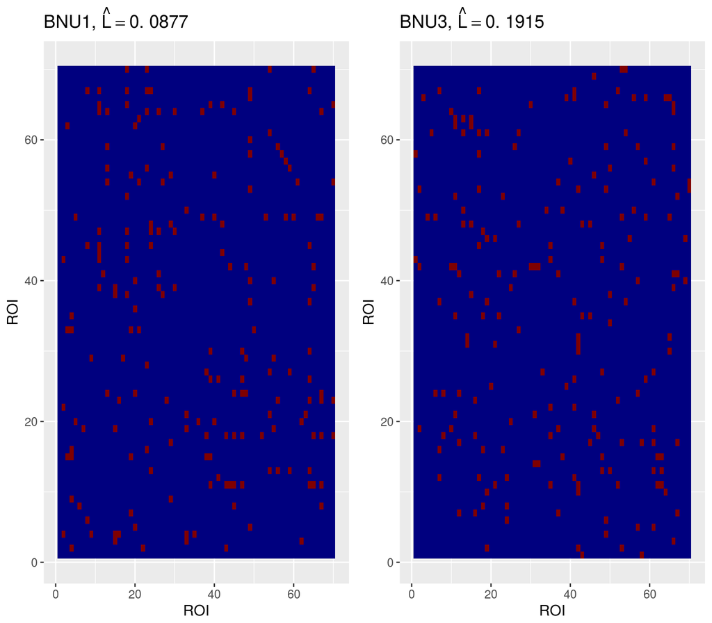

```r
plot.zset(dwi.result$zset, dwi.result$alt.ssgs, dwi.result$alt.lhat)
```

and we visualize the synthetically generated sub-graphs for each dataset from our synthetic bootstrap:

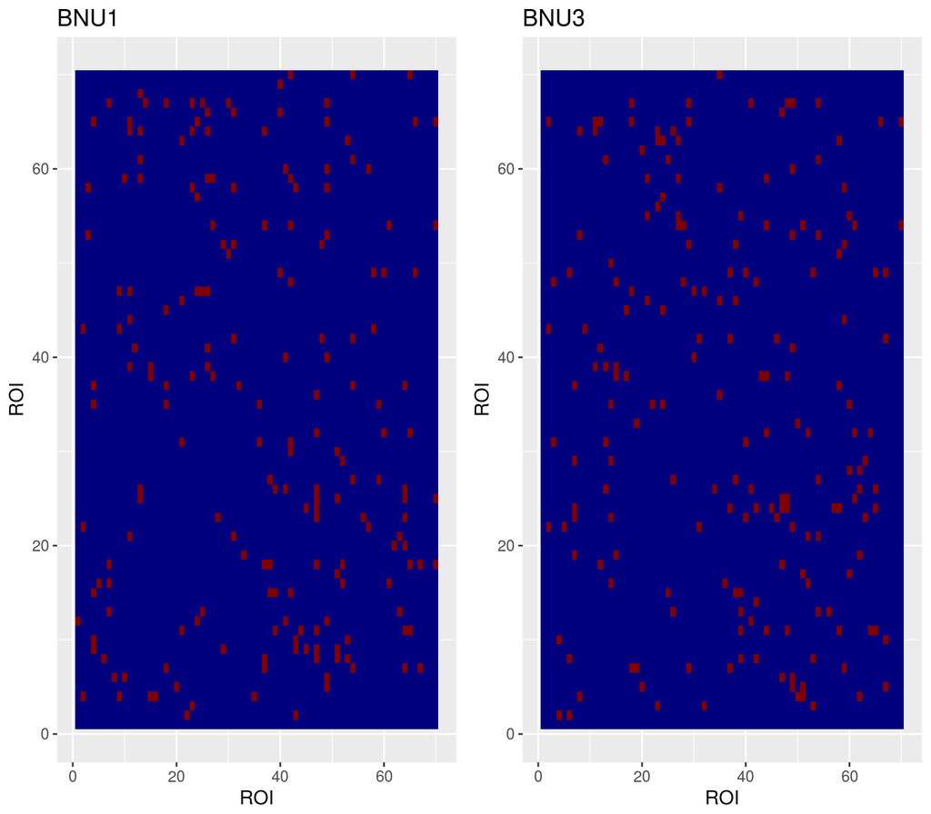

```r
plot.zset(dwi.result$zset, dwi.result$null.ssgs)
```

Along with the globally estimated sub-graph:

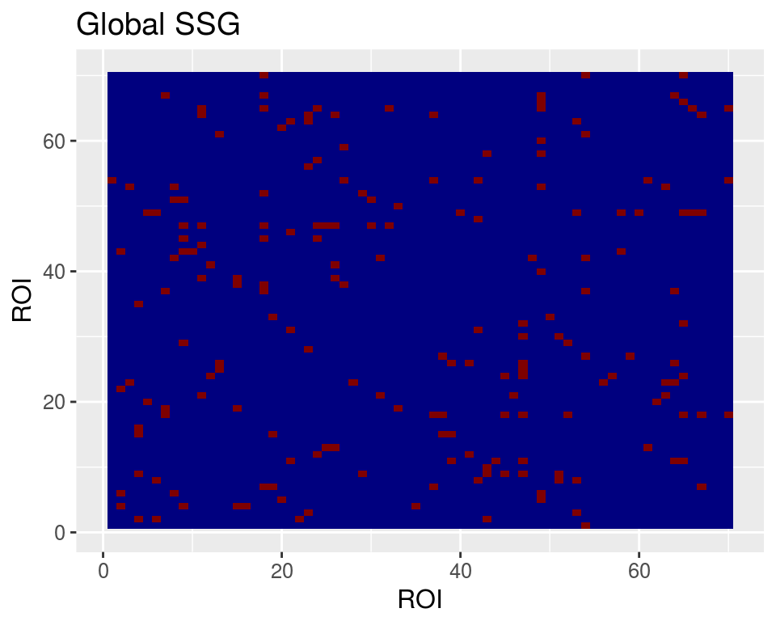

```r
fmriu.plot.plot_graph(dwi.result$global.ssgs,  legend.name=TeX("$I_{uv}$"),
                        title="Global SSG",
                        limits=c(min(dwi.result$global.ssgs), max(dwi.result$global.ssgs)), xlabel = "ROI",
                        ylabel = "ROI") + theme(legend.position=NaN)
```

We visualzize a density estimate of the null, and compare with our observed test statistic, producing a $p$-value as the fraction of statistics under the null that are more contradictory to the null. Since our model attempts to show the similarity between the global and local sub-graphs using the jaccard index, being more contradictory to the null that there is no batch effect means having a lower jaccard score than we observe, so our $p$ is the proportion of test statistics less extreme than the observed statistic:

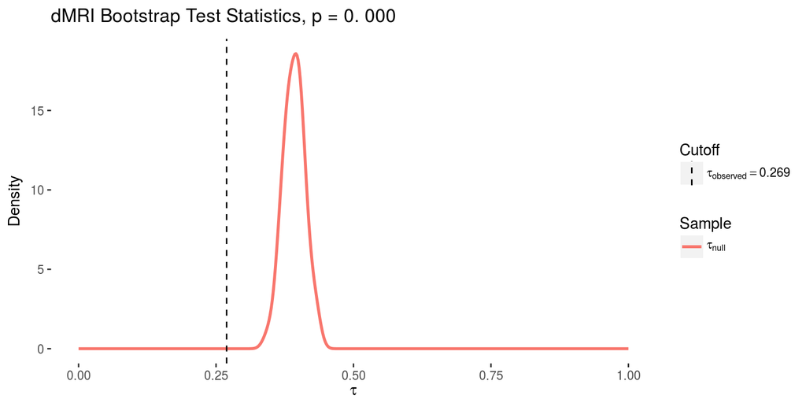

```r
vline = data.frame(x=dwi.result$tstat.alt, type="t")

dat <- data.frame(sample="null", t=dwi.result$tstat.null)
dat$sample <- factor(dat$sample)
labs <- lapply(levels(dat$sample), function(samp) {
  TeX(sprintf("$\\tau_{%s}$", samp))
})
ggplot(data=dat, aes(t, group=sample, color=sample)) +
  geom_line(stat="density", size=1, adjust=1.5) +
  geom_vline(data=vline, aes(xintercept=x, linetype=type)) +
  scale_color_discrete(name="Sample", breaks=dat$sample, labels=labs) +
  scale_linetype_manual(values=c("dashed"), name="Cutoff", breaks=c("t"),
                        labels=lapply(sprintf("$\\tau_{observed} = %.3f", dwi.result$tstat.alt), TeX)) +
  xlab(TeX("$\\tau$")) +
  ylab("Density") +
  scale_x_continuous(limits=c(0, 1)) +
  theme(panel.background=element_rect(fill="#ffffff")) +
  ggtitle(TeX(sprintf("dMRI Bootstrap Test Statistics, $p$ = %.3f", dwi.result$p)))
```

as we can see, the observed $\\tau_{observed}$ is significantly lower than the statistics computed from data simulated under the null.

Finally, we check the number of times a given edge appears across the studies being investigated (simulated or real). We visualize the normalized distribution of the number of times an edge appears under the alternative and the null:

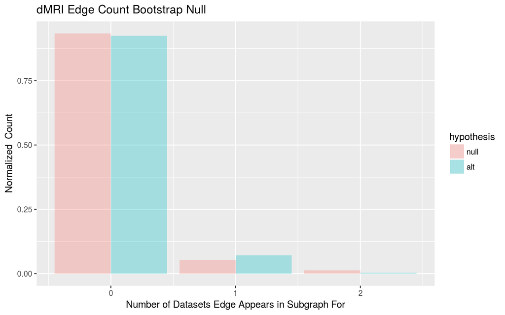

```r
countdat <- rbind(data.frame(hypothesis="null", nds=0:(length(dwi.result$null.counts) - 1), ncount=dwi.result$null.counts),
                  data.frame(hypothesis="alt",nds=0:(length(dwi.result$alt.counts)-1), ncount=dwi.result$alt.counts))
ggplot(data=countdat, aes(x=nds, y=ncount, fill=hypothesis)) +
  geom_bar(stat='identity', alpha=0.3, position='dodge') +
  ylab("Normalized  Count") +
  xlab("Number of Datasets Edge Appears in Subgraph For") +
  ggtitle("dMRI Edge Count Bootstrap Null")
```

### Functional

```r
nroi = 70
atlases = c('desikan-2mm')


fmri.dsets = c('BNU1', 'BNU3')

graphobj <- fmriu.io.collection.open_graphs(basepath='/data/fmri/raw/edgelists/', datasets = fmri.dsets,
                                            atlases = atlases, fmt='edgelist', rtype='array')
```

```
## [1] "opening graphs for BNU1 dataset and desikan-2mm parcellation atlas..."
## [1] "opening graphs for BNU3 dataset and desikan-2mm parcellation atlas..."
```

```r
graphs = graphobj$graphs
```

```r
gcpy = graphs
datasets = graphobj$dataset
subjects = graphobj$subjects
sessions = graphobj$sessions

parse_class <- function(basepath, dsets, subjects) {
  sex = list()
  # disease = list()
  age = list()
  include = c()
  for (dset in dsets) {
    path_to_file = file.path(basepath, paste(dset, "_phenotypic_data.csv", sep=""))
    tab = read.csv(path_to_file)
    tab$SEX[tab$SEX == '#' | is.na(tab$SEX) | is.nan(tab$SEX)] = NaN
    if (dset == 'KKI2009') {
      sexm <- 'M'
    } else if (dset == 'Templeton114') {
      sexm <- 1
    } else {
      sexm <- 2
    }
    tab$AGE_AT_SCAN_1 <- factor(tab$AGE_AT_SCAN_1)
    tab$SEX = tab$SEX == sexm
    tab = tab[complete.cases(tab$SEX),]
    tab$AGE_AT_SCAN_1 = as.numeric(levels(tab$AGE_AT_SCAN_1))[tab$AGE_AT_SCAN_1]
    for (idx in 1:dim(tab)[1]) {
      subid = toString(tab[idx,]$SUBID)
      sex[[subid]] = tab[idx,]$SEX
      age[[subid]] = tab[idx,]$AGE_AT_SCAN_1
      # disease[[subid]] = tab[idx,]$DSM_IV_TR
    }
  }

  sclass = array(NaN, dim=c(length(subjects)))
  ageclass = sclass
  # diseaseclass = sclass
  for (i in 1:length(subjects)) {
    subject = subjects[i]
    subid = sub('^0+(?=[1-9])', '', str_extract(subject, '(?<=sub-).*'), perl=TRUE)
    idx = which(names(sex) == subid)
    if (length(idx) >= 1) {
      sclass[i] <- sex[[subid]]
      ageclass[i] <- age[[subid]]
      # diseaseclass[i] <- disease[[subid]]
    }
  }
  return(list(sex=sclass, age=ageclass))#, disease=diseaseclass))
}

sexpath = '/home/eric/Documents/research/mgc-repos/fmribatch_notes/data/phenotypic_data/'
class = parse_class(sexpath, fmri.dsets, subjects)
sexs = class$sex
# dwi.diseases = class$disease
ages = class$age

fmri.graphs = graphs[!is.nan(ages) & !is.nan(sexs),,]
fmri.datasets = datasets[!is.nan(ages) & !is.nan(sexs)]
fmri.subjects = subjects[!is.nan(ages) & !is.nan(sexs)]
fmri.sessions = sessions[!is.nan(ages) & !is.nan(sexs)]
fmri.ages = ages[!is.nan(ages) & !is.nan(sexs)]
fmri.sexs = sexs[!is.nan(ages) & !is.nan(sexs)]
```

We conduct a synthetic bootstrap investigation following the above procedure:

we first visualize our set of subgraphs computed from each study using the sex class label and study as the batch label:

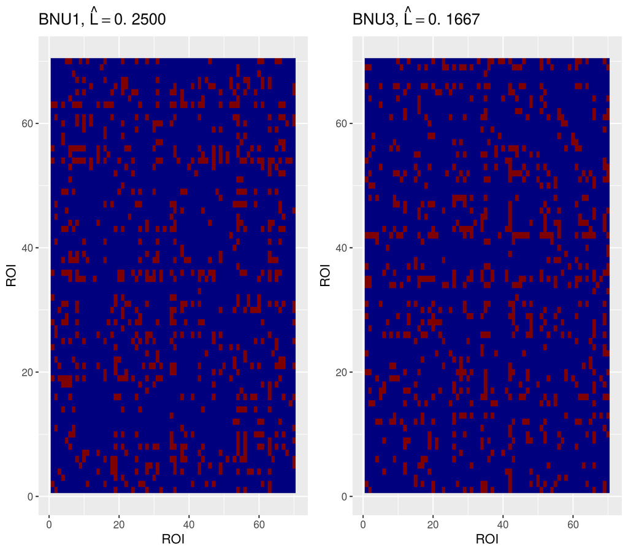

```r
plot.zset(fmri.result$zset, fmri.result$alt.ssgs, fmri.result$alt.lhat)
```

and we visualize the synthetically generated sub-graphs for each dataset from our synthetic bootstrap:

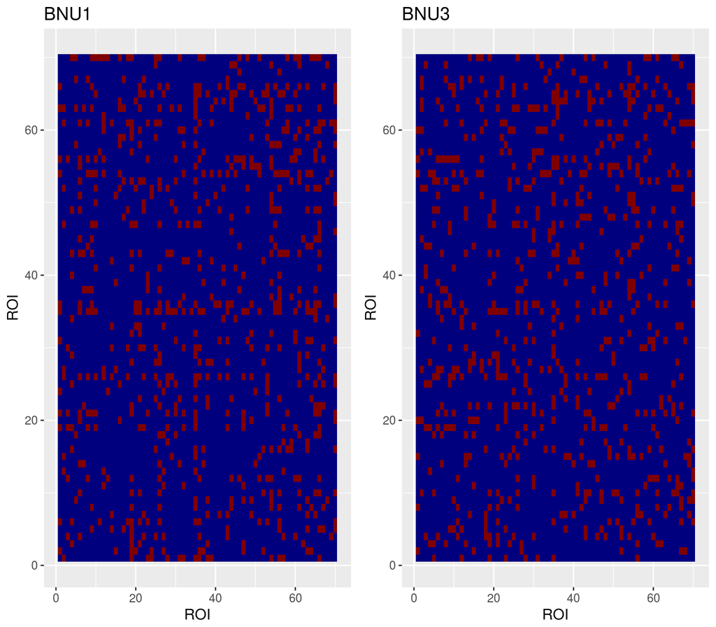

```r
plot.zset(fmri.result$zset, fmri.result$null.ssgs)
```

Along with the globally estimated sub-graph:

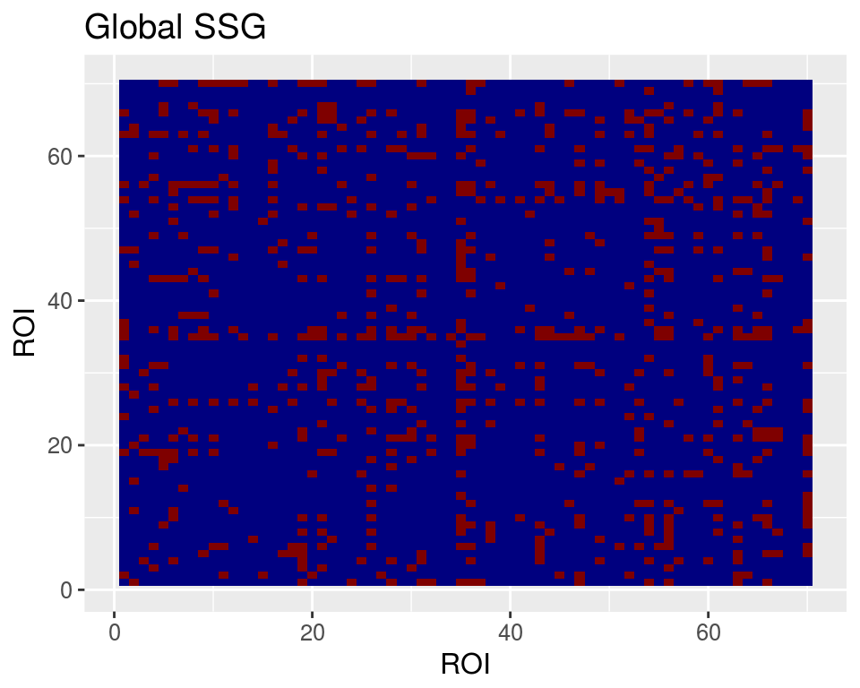

```r
fmriu.plot.plot_graph(fmri.result$global.ssgs,  legend.name=TeX("$I_{uv}$"),
                        title="Global SSG",
                        limits=c(min(fmri.result$global.ssgs), max(fmri.result$global.ssgs)), xlabel = "ROI",
                        ylabel = "ROI") + theme(legend.position=NaN)
```

We visualzize a density estimate of the null, and compare with our observed test statistic, producing a $p$-value as the fraction of statistics under the null that are more contradictory to the null. Since our model attempts to show the similarity between the global and local sub-graphs using the jaccard index, being more contradictory to the null that there is no batch effect means having a lower jaccard score than we observe, so our $p$ is the proportion of test statistics less extreme than the observed statistic:

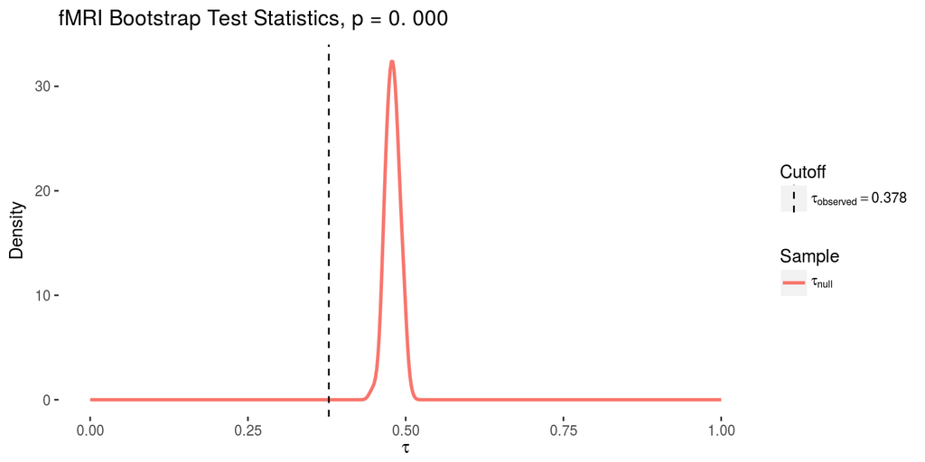

```r
vline = data.frame(x=fmri.result$tstat.alt, type="t")

dat <- data.frame(sample="null", t=fmri.result$tstat.null)
dat$sample <- factor(dat$sample)
labs <- lapply(levels(dat$sample), function(samp) {
  TeX(sprintf("$\\tau_{%s}$", samp))
})
ggplot(data=dat, aes(t, group=sample, color=sample)) +
  geom_line(stat="density", size=1, adjust=1.5) +
  geom_vline(data=vline, aes(xintercept=x, linetype=type)) +
  scale_color_discrete(name="Sample", breaks=dat$sample, labels=labs) +
  scale_linetype_manual(values=c("dashed"), name="Cutoff", breaks=c("t"),
                        labels=lapply(sprintf("$\\tau_{observed} = %.3f", fmri.result$tstat.alt), TeX)) +
  xlab(TeX("$\\tau$")) +
  ylab("Density") +
  scale_x_continuous(limits=c(0, 1)) +
  theme(panel.background=element_rect(fill="#ffffff")) +
  ggtitle(TeX(sprintf("fMRI Bootstrap Test Statistics, $p$ = %.3f", fmri.result$p)))
```

as we can see, the observed $\\tau_{observed}$ is significantly lower than the statistics computed from data simulated under the null.

Finally, we check the number of times a given edge appears across the studies being investigated (simulated or real). We visualize the normalized distribution of the number of times an edge appears under the alternative and the null:

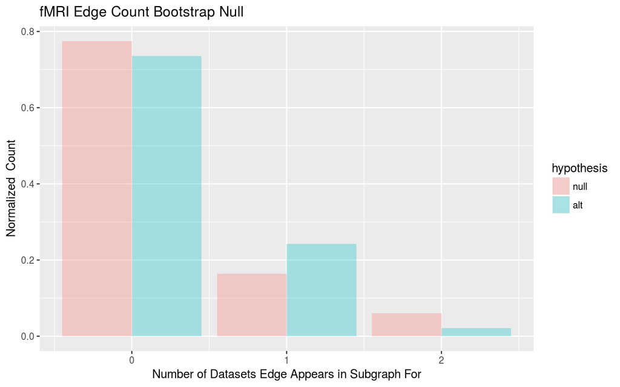

```r
countdat <- rbind(data.frame(hypothesis="null", nds=0:(length(fmri.result$null.counts) - 1), ncount=fmri.result$null.counts),
                  data.frame(hypothesis="alt",nds=0:(length(fmri.result$alt.counts)-1), ncount=fmri.result$alt.counts))
ggplot(data=countdat, aes(x=nds, y=ncount, fill=hypothesis)) +
  geom_bar(stat='identity', alpha=0.3, position='dodge') +
  ylab("Normalized  Count") +
  xlab("Number of Datasets Edge Appears in Subgraph For") +
  ggtitle("fMRI Edge Count Bootstrap Null")
```

# Across Modality

Below, we test whether the batch effect is more significant in the dMRI than the fMRi connectomes. We do this by examining whether the difference in the observed vs the null test statistics is greater in the dMRI than the fMRI.

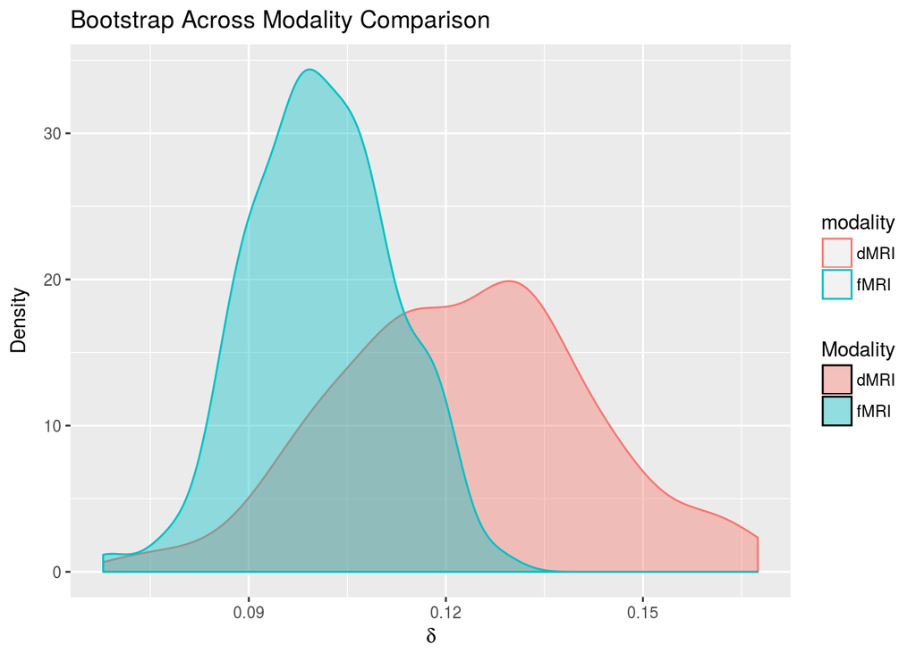

```r
dwi.delta <- dwi.result$tstat.null - dwi.result$tstat.alt
fmri.delta <- fmri.result$tstat.null - fmri.result$tstat.alt

across.delta <- rbind(data.frame(modality="dMRI", delta=dwi.delta), data.frame(modality="fMRI", delta=fmri.delta))
ggplot(across.delta, aes(delta, group=modality, color=modality, fill=modality)) +
  geom_density(alpha=0.4) +
  xlab(TeX("$\\delta$")) +
  ylab(TeX("Density")) +
  ggtitle("Bootstrap Across Modality Comparison") +
  scale_fill_discrete(name="Modality")
```

```r
t.test(dwi.delta, fmri.delta, alternative="greater", var.equal=FALSE)
```

```
##
##  Welch Two Sample t-test
##
## data:  dwi.delta and fmri.delta
## t = 13.826, df = 314.69, p-value < 2.2e-16
## alternative hypothesis: true difference in means is greater than 0
## 95 percent confidence interval:
##  0.01902236        Inf
## sample estimates:
## mean of x mean of y
## 0.1226478 0.1010482
```